# Project-1 Corona_virus

```python
import pandas as pd
import numpy as np
import seaborn as sns
import matplotlib.pyplot as plt
```

```python
df=pd.read_csv("C:/Users/Yash/Desktop/covid_19_data.csv")
```

```python
df
```

|  | SNo | ObservationDate | Province/State | Country/Region | Last Update | Confirmed | Deaths | Recovered |
| --- | --- | --- | --- | --- | --- | --- | --- | --- |
| 0 | 1 | 01/22/2020 | Anhui | Mainland China | 1/22/2020 17:00 | 1.0 | 0.0 | 0.0 |
| 1 | 2 | 01/22/2020 | Beijing | Mainland China | 1/22/2020 17:00 | 14.0 | 0.0 | 0.0 |
| 2 | 3 | 01/22/2020 | Chongqing | Mainland China | 1/22/2020 17:00 | 6.0 | 0.0 | 0.0 |
| 3 | 4 | 01/22/2020 | Fujian | Mainland China | 1/22/2020 17:00 | 1.0 | 0.0 | 0.0 |
| 4 | 5 | 01/22/2020 | Gansu | Mainland China | 1/22/2020 17:00 | 0.0 | 0.0 | 0.0 |
| ... | ... | ... | ... | ... | ... | ... | ... | ... |
| 306424 | 306425 | 05/29/2021 | Zaporizhia Oblast | Ukraine | 2021-05-30 04:20:55 | 102641.0 | 2335.0 | 95289.0 |
| 306425 | 306426 | 05/29/2021 | Zeeland | Netherlands | 2021-05-30 04:20:55 | 29147.0 | 245.0 | 0.0 |
| 306426 | 306427 | 05/29/2021 | Zhejiang | Mainland China | 2021-05-30 04:20:55 | 1364.0 | 1.0 | 1324.0 |
| 306427 | 306428 | 05/29/2021 | Zhytomyr Oblast | Ukraine | 2021-05-30 04:20:55 | 87550.0 | 1738.0 | 83790.0 |
| 306428 | 306429 | 05/29/2021 | Zuid-Holland | Netherlands | 2021-05-30 04:20:55 | 391559.0 | 4252.0 | 0.0 |

306429 rows × 8 columns

```python
df.isna().sum()
```

```
SNo                    0
ObservationDate        0
Province/State     78103
Country/Region         0
Last Update            0
Confirmed              0
Deaths                 0
Recovered              0
dtype: int64
```

```python
for i in df.columns:
    if df[i].dtypes==object:
        df[i]=df[i].fillna(df[i].mode()[0])
    else:
        df[i]=df[i].fillna(df[i].mean())
```

```python
df.isna().sum()
```

```
SNo                0
ObservationDate    0
Province/State     0
Country/Region     0
Last Update        0
Confirmed          0
Deaths             0
Recovered          0
dtype: int64
```

```python
df.columns
```

```
Index(['SNo', 'ObservationDate', 'Province/State', 'Country/Region',
       'Last Update', 'Confirmed', 'Deaths', 'Recovered'],
      dtype='object')
```

1.What is the total number of confirmed cases worldwide?

```python
df['Confirmed'].sum()
```

```
26252051758.0
```

2.How many deaths have been reported globally?

```python
df['Deaths'].sum()
```

```
624013017.0
```

What is the total number of recovered cases worldwide?

```python
df['Recovered'].sum()
```

```
15450237912.0
```

3.How many countries/regions are represented in the dataset?

```python
df['Country/Region'].unique()
```

```
array(['Mainland China', 'Hong Kong', 'Macau', 'Taiwan', 'US', 'Japan',
       'Thailand', 'South Korea', 'China', 'Kiribati', 'Singapore',
       'Philippines', 'Malaysia', 'Vietnam', 'Australia', 'Mexico',
       'Brazil', 'Colombia', 'France', 'Nepal', 'Canada', 'Cambodia',
       'Sri Lanka', 'Ivory Coast', 'Germany', 'Finland',
       'United Arab Emirates', 'India', 'Italy', 'UK', 'Russia', 'Sweden',
       'Spain', 'Belgium', 'Others', 'Egypt', 'Iran', 'Israel', 'Lebanon',
       'Iraq', 'Oman', 'Afghanistan', 'Bahrain', 'Kuwait', 'Austria',
       'Algeria', 'Croatia', 'Switzerland', 'Pakistan', 'Georgia',
       'Greece', 'North Macedonia', 'Norway', 'Romania', 'Denmark',
       'Estonia', 'Netherlands', 'San Marino', ' Azerbaijan', 'Belarus',
       'Iceland', 'Lithuania', 'New Zealand', 'Nigeria', 'North Ireland',
       'Ireland', 'Luxembourg', 'Monaco', 'Qatar', 'Ecuador',
       'Azerbaijan', 'Czech Republic', 'Armenia', 'Dominican Republic',
       'Indonesia', 'Portugal', 'Andorra', 'Latvia', 'Morocco',
       'Saudi Arabia', 'Senegal', 'Argentina', 'Chile', 'Jordan',
       'Ukraine', 'Saint Barthelemy', 'Hungary', 'Faroe Islands',
       'Gibraltar', 'Liechtenstein', 'Poland', 'Tunisia', 'Palestine',
       'Bosnia and Herzegovina', 'Slovenia', 'South Africa', 'Bhutan',
       'Cameroon', 'Costa Rica', 'Peru', 'Serbia', 'Slovakia', 'Togo',
       'Vatican City', 'French Guiana', 'Malta', 'Martinique',
       'Republic of Ireland', 'Bulgaria', 'Maldives', 'Bangladesh',
       'Moldova', 'Paraguay', 'Albania', 'Cyprus', 'St. Martin', 'Brunei',
       'occupied Palestinian territory', "('St. Martin',)",
       'Burkina Faso', 'Channel Islands', 'Holy See', 'Mongolia',
       'Panama', 'Bolivia', 'Honduras', 'Congo (Kinshasa)', 'Jamaica',
       'Reunion', 'Turkey', 'Cuba', 'Guyana', 'Kazakhstan',
       'Cayman Islands', 'Guadeloupe', 'Ethiopia', 'Sudan', 'Guinea',
       'Antigua and Barbuda', 'Aruba', 'Kenya', 'Uruguay', 'Ghana',
       'Jersey', 'Namibia', 'Seychelles', 'Trinidad and Tobago',
       'Venezuela', 'Curacao', 'Eswatini', 'Gabon', 'Guatemala',
       'Guernsey', 'Mauritania', 'Rwanda', 'Saint Lucia',
       'Saint Vincent and the Grenadines', 'Suriname', 'Kosovo',
       'Central African Republic', 'Congo (Brazzaville)',
       'Equatorial Guinea', 'Uzbekistan', 'Guam', 'Puerto Rico', 'Benin',
       'Greenland', 'Liberia', 'Mayotte', 'Republic of the Congo',
       'Somalia', 'Tanzania', 'The Bahamas', 'Barbados', 'Montenegro',
       'The Gambia', 'Kyrgyzstan', 'Mauritius', 'Zambia', 'Djibouti',
       'Gambia, The', 'Bahamas, The', 'Chad', 'El Salvador', 'Fiji',
       'Nicaragua', 'Madagascar', 'Haiti', 'Angola', 'Cabo Verde',
       'Niger', 'Papua New Guinea', 'Zimbabwe', 'Cape Verde',
       'East Timor', 'Eritrea', 'Uganda', 'Bahamas', 'Dominica', 'Gambia',
       'Grenada', 'Mozambique', 'Samoa', 'Syria', 'Timor-Leste', 'Belize',
       'Laos', 'Libya', 'Diamond Princess', 'Guinea-Bissau', 'Mali',
       'Saint Kitts and Nevis', 'West Bank and Gaza', 'Burma',
       'MS Zaandam', 'Botswana', 'Burundi', 'Sierra Leone', 'Malawi',
       'South Sudan', 'Sao Tome and Principe', 'Yemen', 'Comoros',
       'Tajikistan', 'Lesotho', 'Solomon Islands', 'Marshall Islands',
       'Vanuatu', 'Micronesia'], dtype=object)
```

5.What is the trend of confirmed cases over time globally?

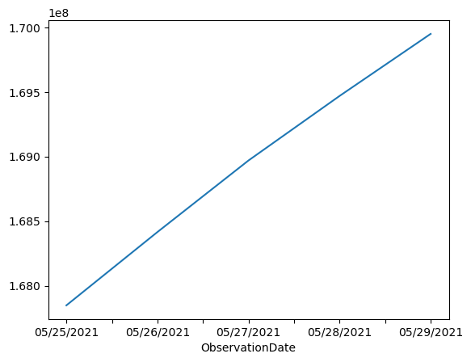

```python
df.groupby('ObservationDate')['Confirmed'].sum().sort_values().tail(5).plot(kind='line')
```

6.Which province/state has reported the highest number of confirmed cases?

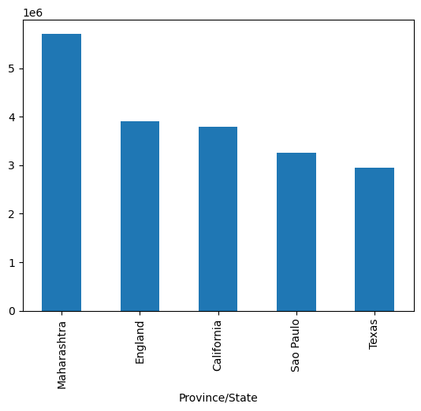

```python
df.groupby('Province/State')['Confirmed'].max().sort_values(ascending=False).head().plot(kind='bar')
```

7.Which country/region has the highest number of deaths?

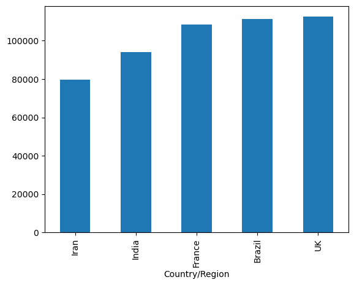

```python
df.groupby('Country/Region')['Deaths'].max().sort_values().tail(5).plot(kind='bar')
```

8.How does the number of confirmed cases vary across different provinces/states?

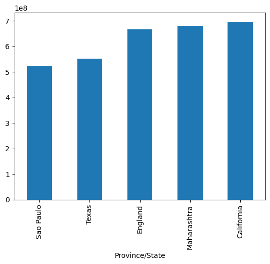

```python
df.groupby('Province/State')['Confirmed'].sum().sort_values().tail(5).plot(kind='bar')
```

9.What is the trend of deaths over time globally?

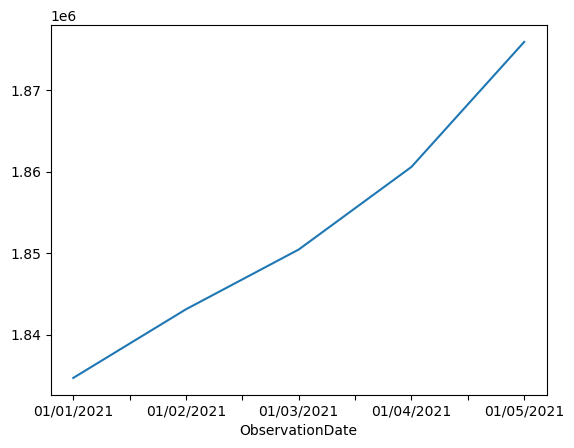

```python
df.groupby('ObservationDate')['Deaths'].sum().head(5).plot(kind='line')
```

10.Which country/region has the highest number of recovered cases?

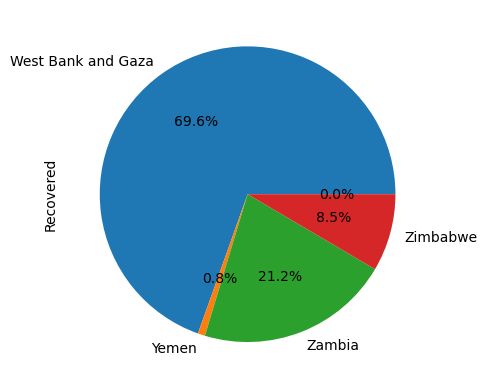

```python
df.groupby('Country/Region')['Recovered'].max().tail().plot(kind='pie',autopct='%1.1f%%')
```

11.How does the number of recovered cases vary across different countries/regions?

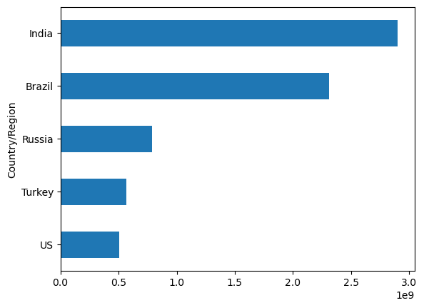

```python
df.groupby('Country/Region')['Recovered'].sum().sort_values().tail().plot(kind='barh')
```

12.What is the distribution of confirmed cases by country/region?

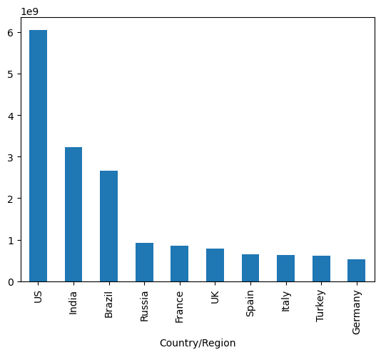

```python
df.groupby('Country/Region')['Confirmed'].sum().sort_values(ascending=False).head(10).plot(kind='bar')
```

13.Is there a correlation between the number of confirmed cases and deaths?

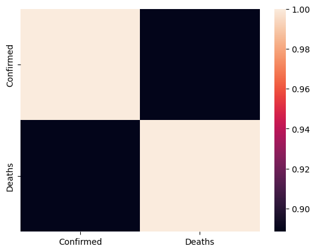

```python
sns.heatmap(df[['Confirmed','Deaths']].corr())
```

14.Is there a correlation between the number of confirmed cases and recovered cases?

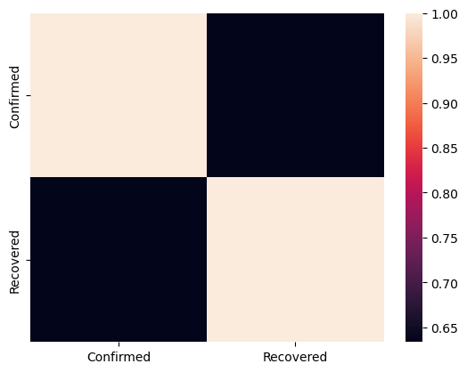

```python
sns.heatmap(df[['Confirmed','Recovered']].corr())
```

15.How does the mortality rate vary across different countries/regions?

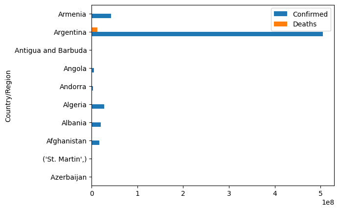

```python
df.groupby('Country/Region')[['Confirmed','Deaths']].sum().head(10).plot(kind='barh')
```

16.How does the recovery rate vary across different countries/regions?

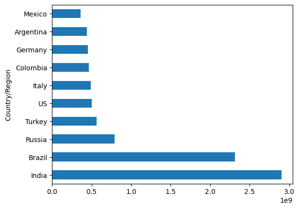

```python
df.groupby('Country/Region')['Recovered'].sum().sort_values(ascending=False).head(10).plot(kind='barh')
```

17.What is the trend of new confirmed cases over time globally?

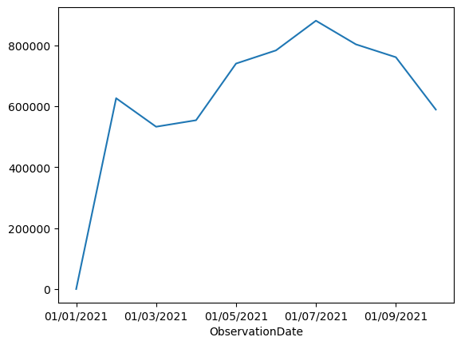

```python
df.groupby('ObservationDate').sum()['Confirmed'].diff().fillna(0).head(10).plot(kind='line')
```

18.How does the fatality rate vary across different provinces/states?

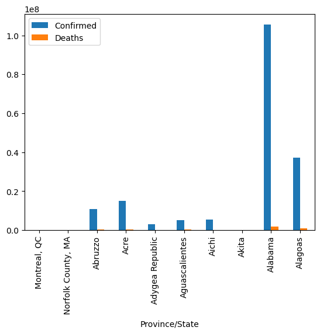

```python
df.groupby('Province/State')[['Confirmed','Deaths']].sum().head(10).plot(kind='bar')
```

19.How does the recovery rate vary across different provinces/states?

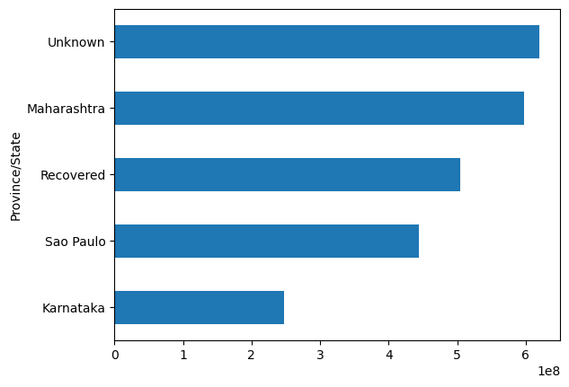

```python
df.groupby('Province/State')['Recovered'].sum().sort_values().tail().plot(kind='barh')
```

20.What is the trend of active cases over time globally?

```python
df['Active']=df['Confirmed']-df['Recovered']-df['Deaths']
```

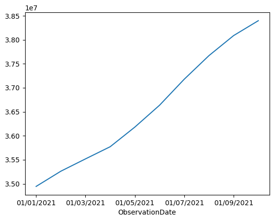

```python
df.groupby('ObservationDate')['Active'].sum().head(10).plot(kind='line')
```